# Module 10: Creating a Graphical User Interface with Google Earth Engine

# 5 “*Delta Watch*”, an RMET Adaptation.

Much of the complexity of the RMET code comes from the fact that it does so much. By looking at multiple indices across multiple sensors you end up having to write out many unique functions. For our adaptation, we are going to simplify the process in the following ways:

- *Define the area of interest*: Work with three delta systems
- *Bring together lots of imagery*: Use only Landsat imagery
- *Generate indices from imagery*: Use only NDVI

The other elements of the RMET code will stay the same in this new addition.

- *Define year/years of interest*
- *Compare imagery*
- *Visualize imagery*

It is essential to know what you want the GUI to do before you start creating it. As you will see, GUI development is an inherently interrelated process. This means the GUI and the geoprocessing components need to be developed at the same time in order to troubleshoot how they are working together. The more planning you do up front, the more time it will save you in the long term. Through the rest of this module, we will be describing each GUI element and its interrelated geoprocessing methods at the same time. This process reflects how you would build a GUI yourself: add an element, see it if works, move on to the next element.

## 5.1 Global Variables

It is a bit tricky to conceptualize the idea that elements of your script can exist exclusively in a function. Yet, because we will rely so heavily on functions, it becomes essential to understand when you need to connect elements that exist inside a function to other elements in your local environment. A way of building this relationship is by declaring variables in your script, then defining those variables in the functions. Below is an example of the variables that are defined within a function but are called upon by other elements in the script that exist in the local environment.

We will refer to these elements as global variables because they are present in both the server and client side environments.

*Clear your script in the code editor so you are working with a clean slate.*

```javascript
/*
Global Variables
*/
var aoi,
    areaOfInterest,
    Fimageyr1,Fimageyr2,Fimageyr3,
    geometry,
    thresh,
    yr1,yr2,yr3;
```

If you were building this code from scratch, you would add these variable as needed. All these variables will be declared within functions at some point in the code.

## 5.2 Visualization Parameters

Much like the global variables, defining the visualizing parameters is something you will do as the code develops. That said, for clarity and organizational purposes we will declare all the visualization elements at the beginning of the script.

```javascript
/*
Visualization parameters
*/

var VEG = {"opacity":1,"palette":["2ddc0d"],"min":0,"max":1};
var MG = {"opacity":1, "palette":["ffffff", "085a16"], "min":0, "max":2};
var LG = {"opacity":1, "palette":["ff7c0b", "ffffff"], "min":-2, "max":0};
var visNDVI = {min: -1, max: 1, palette: ['blue', 'white', 'green']};
var FLG = {"opacity":1, "palette":[ "ffffff", "ff7c0b"], "min":0, "max":2};
```

At this point, all the predefined variables that will be used in the code are present. We will now move on to developing the functionality of “*Delta Watch*”.

## 5.3 Visualizing the Graphic User Interface.

As part of the planning process, it is a good idea to draw out what you want the end product to look like in as much detail as possible. In this case, we can create a simplified diagram that shows the component parts of the GUI we will be creating.

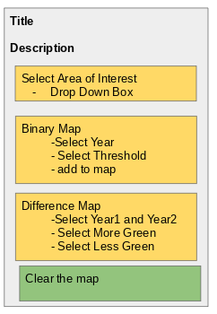

*Example conceptual diagram of what the “Delta Watch” GUI will do.*

The first component ‘title’ and ‘description’ are not connected to any geoprocessing so we will start there.

```javascript
/*
Create the panel
*/

// Generate main panel and add it to the map.
var panel = ui.Panel({style: {width:'33.333%'}});
ui.root.insert(0,panel);

// Define title and description.
var intro = ui.Label('Delta Watch: An Example GEE GUI ',
  {fontWeight: 'bold', fontSize: '24px', margin: '10px 5px'}
);
var subtitle = ui.Label('Use 30 m Landsat 5,7,8 imagery to'+
  ' visualize changes in delta vegetation patterns over time.'+
  ' Select from multiple area of interest and type of visualization; single year binary '+
  ' or change over time.', {});

// Add title and description to the panel.
panel.add(intro).add(subtitle);
```

The first step is creating the panel and adding it to the map. The ‘0’ in the `ui.root.insert()` function will place the panel on the left side of the map. A value ‘1’ will place on the right. We then define `ui.Label` elements that contain the text we want for the title and description of the project. The final line adds these elements to the panel and order matters. With this we can run the code and the title and description will appear on the new panel on the map.

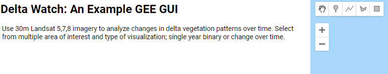

*This initial step of the GUI development. A panel with descriptive text about the function of the tool we are building.*

## 5.4 Defining the Area of Interest

For this project we are examining three deltas around the world

**Colorado River Delta, USA/Mexico** The Colorado River is a heavily dammed and over appropriated water body. This means that more often than not the river does not make it to the delta. In recent years however, actions have been taken to ensure water from the Colorado is reaching the Sea of Cortez. With *“Delta Watch”* completed, we can check to see if these flows have been having an effect on vegetation in the delta.

**Nile River Delta, Egypt** One of the most consistently farmed agricultural areas in the world, the Nile River delta was unique for its consistency in water flow over time. However, the construction of the Awsan High Dam in the 1960s has dramatically altered the flow regimes of the river and it is possible that Landsat imagery will capture some geomorphic events that are still occurring as a result of the change in flow regimes over 50 years ago.

**Betsiboka River Delta, Madagascar** The Betsiboka River is an undammed waterway in north central Madagascar. It is known for its unique water color and very large delta. The color of the water and character of the delta are due to massive deforestation which began in the 1950s within the watershed. As a result of change in sediment load and natural flow regime, we can expect to see a very dynamic deltaic system at the mouth of the Betsiboka.

```javascript
/*
Define study areas.
*/
// Generate polygons for each study region.
var colo = ee.Geometry.Polygon([[-115.29,32.20], [-114.89,31.17],
   [-114.40,31.64], [-115.14,32.19], [-115.29,32.20]]),
    nile = ee.Geometry.Polygon([[28.76,31.49],[30.69,29.91],
      [31.52, 29.96],[32.89,31.43],[31.00,31.76],[28.76,31.49]]),
    bets = ee.Geometry.Polygon([[46.19,-15.66],[46.25,-16.04],
      [46.51,-16.15],[46.70,-16.06],[46.19,-15.66]]);

// Define labels for each study region.
var COLO = 'Colorado River Delta',
    NILE = 'Nile River Delta',
    BETS = 'Betsiboka River Delta';
```

This code generates simple geometry features to define our areas of interest and generates labels that we will use in the drop down box from area of interest(AOI) selection.

```javascript
/*
Select Area of INTEREST
*/

// Define the select button for the AOI
var selectAoi = ui.Select({
  items:[COLO,NILE,BETS],
  placeholder:'Select area of interest',
  });

// Add a label.
var selectSIAOI = ui.Label({value:'Select area of interest',
style: {fontSize: '18px', fontWeight: 'bold'}});

// Add the select AOI panel to the map panel.
panel.add(selectSIAOI)
    .add(selectAoi);
```

In the script above, we use the `ui.select()` widget to generate a drop down box that lists the three variable representing our three study areas. We then create a label to identify what should be done at this step. After this, we add our widget and label to the existing panel feature. The order in which we add the elements to the panel determines the position where they are printed on the label.

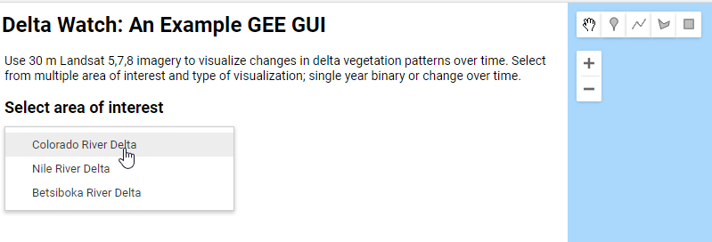

*The drop down element will allow users to define which delta they want to view.*

At this point, the GUI is only referencing local variables; there is no real interaction between the elements yet. Therefore, if you run the script, you can select an AOI. But doing so does not trigger any events. In the next section we will cover the primary geoprocessing code that underlay this GUI.

## 5.5 Nested Functions

As we mentioned before, all the processing within the RMET tool requires some type of user input. This means that most of the processes need to be written as functions to be flexible in the information they accept. These functions are often nested within different functions. Understanding the structure of nested functions will require drafting a work flow to know what elements are required and when. Below is an example of the nested components of our first function which does most of the computation for the *“Delta Watch”* GUI. It is a big function with lots of moving parts, hence the diagram.

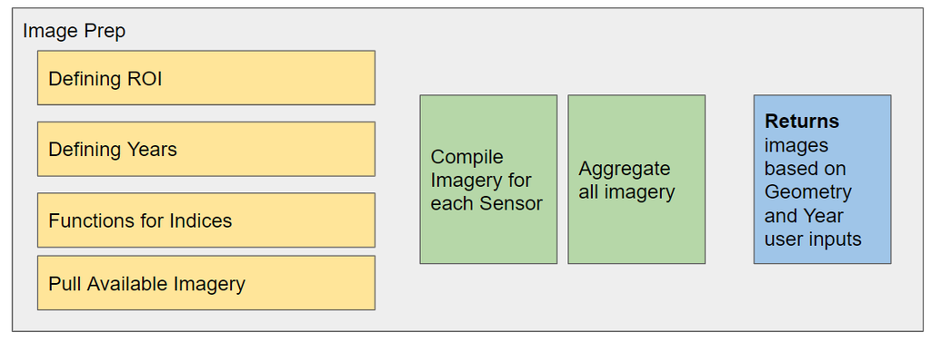

*A conceptual diagram of the primary geoprocessing function in the *“Delta Watch”* code.*

The end result of this process is a set of imagery that matches the year and region that the user selected. From that the other aspects of the code will take that those outputs and produce the added value products that we are interested in. A binary map of NDVI based on a user defined threshold value for a selected year and/or a change map of NDVI over time.

Here we begin to build up this function by adding component parts.

```javascript
// Container function to create Image for mapping.
function applyFilter(){

}
```

The first step is creating a wrapper. A wrapper is a term used to define a feature that will hold mutliple functions present in this step. By using the `applyFilter()` function as a wrapper we can nest all the geoprocessing steps within a single function. This will allow us to call a single element to execute a full list of unique functions and adds clarity to the code further on.

### 5.5.1 Defining the Region of Interest

The first element of our `applyFilter` function is defining the area of interest. As you add these code chucks to your script be sure they are contained within the curly brackets “{}” of the `applyFilter` function.

```javascript
/*
Defining the area of interest
*/

function setAreaOfInterest(){
  aoi = selectAoi.getValue();
  if (aoi == COLO){
      areaOfInterest = colo;
  }//sets the area to nile river delta
  else if(aoi == NILE){
      areaOfInterest = nile;
  }//sets the area of interest to
  else if (aoi == BETS){
      areaOfInterest = bets;
  }
};

setAreaOfInterest();

geometry = areaOfInterest
```

The `setAreaOfInterest()` function uses the `getValue()` function to declare one of the predefined locations as the aoi object. Then through a series of clause statements, the locally defined variable *areaOfInterest* is set equal to the geometry of the selected location. After running the function `setAreaOfInterest()` we define the `geometry` object to be equal to the `areaOfInterest` object. We will use the globally defined object `geometry` in more functions down the line.

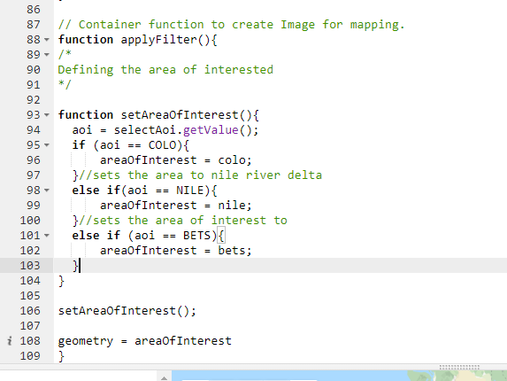

*The `setAreaOfInterest()` function is held within the `applyFilter()`. The next few sections of code will occur inside the `applyFilter()` function as well.*

### 5.5.2 Defining the Years

```javascript
/*
Defining years for image selection
*/
    yr1 = selectYr1.getValue(); //Input for Landsat Binary Map
    yr2 = selectYr2.getValue(); //Input for Landsat Change Map Start Year
    yr3 = selectYr3.getValue(); //Input for Landsat Change Map End Year
```

In this case the variables `selectYr1, selectYr2` and `selectYr3` are defined in the GUI and are set by the user. We want to retrieve these values and declare them as one of the global variables we established early. This is relatively straightforward. The variables `yr1, yr2` and `yr3` were declared earlier using the `var yr1` structure. Because of this we can set those elements equal to the value returned by the `getValue()` function.

### 5.5.3 Collecting the Imagery

Now that we have established the geometry and the year, we can compile our imagery. We will do this by constructing a dictionary that contains a single image for each year across the Landsat 5,7, and 8 collections. This is an adaptation of the dictionary we first used in [Module 8](https://ecodata.nrel.colostate.edu/gdpe-gee-remote-sensing-lessons/module8-timeSeries.html).

```javascript
/*
Creating image dictionaries.
*/

var constructLSDict = function(geometry)
  /*
  This function takes in a geometry feature from the GUI and uses it to
  generate a dictionary of median reduce images for the specified date
  range.
  inputs
  geometry = defined by the GUI
  Features to change
  y_list = set based on sensor type
  imagecollection = unique id for collection type
  filterDate = cat() this is used to refine the month and day of start and end time
  With adaptation this should be flexible across sensors and times
  */
  {
  var startMonth = "-04-05"
  var endMonth = "-09-30"
  // Construct a dictionary for landsat 8 imagery.
  var y_list = ee.List.sequence(2013, 2018)
  var ystr_list = y_list.map(function(y){return ee.Number(y).format('%1d')})
  var ls8 = y_list.map(function(y){return ee.ImageCollection('LANDSAT/LC08/C01/T1_SR')
                                          .filterDate(ee.String(ee.Number(y).format('%1d')).cat(startMonth),
                                                      ee.String(ee.Number(y).format('%1d')).cat(endMonth))
                                          .filterBounds(geometry)
                                          .filterMetadata('CLOUD_COVER', 'less_than', 30)
                                          .median()})
  var ls8_dict = ee.Dictionary.fromLists(ystr_list, ls8);

  // Construct a dictionary for LS7 imagery
  var y_list7 = ee.List.sequence(2012, 2012)
  var ystr_list7 = y_list7.map(function(y){return ee.Number(y).format('%1d')})
  var ls7 = y_list7.map(function(y){return ee.ImageCollection('LANDSAT/LE07/C01/T1_SR')
                                          .filterDate(ee.String(ee.Number(y).format('%1d')).cat(startMonth),
                                                      ee.String(ee.Number(y).format('%1d')).cat(endMonth))
                                          .filterBounds(geometry)
                                          .filterMetadata('CLOUD_COVER', 'less_than', 30)
                                          .median()})
  var ls7_dict = ee.Dictionary.fromLists(ystr_list7, ls7);

  // Combine the LS8 and LS7 dictionaries.
  var ls8_ls7_dict = ls8_dict.combine(ls7_dict)

  // Construct a dictionary for Landsat 5.
  var y_list5 = ee.List.sequence(1984,2011)
  var ystr_list5 = y_list5.map(function(y){return ee.Number(y).format('%1d')})
  var ls5 = y_list5.map(function(y){return ee.ImageCollection('LANDSAT/LT05/C01/T1_SR')
                                          .filterDate(ee.String(ee.Number(y).format('%1d')).cat(startMonth),
                                                      ee.String(ee.Number(y).format('%1d')).cat(endMonth))
                                          .filterBounds(geometry)
                                          .filterMetadata('CLOUD_COVER', 'less_than', 30)
                                          .median()})
  var ls5_dict = ee.Dictionary.fromLists(ystr_list5, ls5);
  // Combine the LS5 with the LS8/7 dictionary
  var LS_Dict = ls8_ls7_dict.combine(ls5_dict)

  return(LS_Dict)
}
```

For each sensor we are generating a median reduced image for each year with imagery captured between April and September. This time frame represents the growing season along the Colorado River. At 32 degrees north it is the furthest site from the equator and is likely to have the most distinct growing season of our river delta ecosystems. That said, were working under the assumption that our data range will also capture the changes in vegetation for the Betsiboka River Delta in Madagascar, which is in the southern hemisphere.

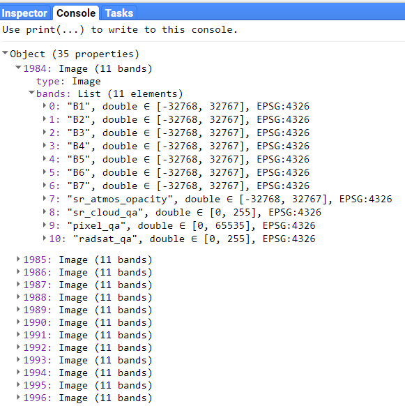

*Example print statement of the Landsat dictionary. There are 35 years of data available and each year has a single multiband image.*

### 5.5.4 Defining the Indices

In the step above we declared a function. In the next step we will generate a few additioal functions that will be used to produce NDVI values based on the output of the `constructLSDict` function.

```javascript
/*
Generating indices
*/
// A function to compute NDVI for Landsat 5 and 7.
var NDVI57 = function(image) {
  return image.normalizedDifference(["B4","B3"]).rename("NDVI");
};

// A function to compute NDVI for Landsat 8.
var NDVI8 = function(image) {
  return image.normalizedDifference(["B5","B4"]).rename("NDVI");
};
```

### 5.5.5 Define the Image Collection to Use

We will now define a function that takes the year and geometry and return a single image.

```javascript
/*
Selecting bands based on years
*/

var selectYearAddBands = function(dictionary, year, geometry)
{
    if (year >= 2012) {
      var imageYear = ee.Image(dictionary.get(year)).clip(geometry)
      var outImage = imageYear.addBands(NDVI8(imageYear))
    } else if (year == 2011) {
      var imageYear = ee.Image(dictionary.get(year)).clip(geometry)
      var outImage = imageYear.addBands(NDVI57(imageYear))
    } else {
      var imageYear = ee.Image(dictionary.get(year)).clip(geometry)
      var outImage = imageYear.addBands(NDVI57(imageYear))
    }
  return (outImage)
};
```

This function is effectively a conditional statement that uses the input year to determine what year to use and therefore determine which NDVI algorithm to apply. In our case, we are using a single band, NDVI, so this is not the most efficient method but it does allow for the flexibility of being able to add more bands down the line.

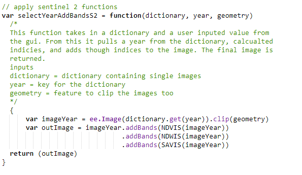

*An example from the RMET code. The `selectYearAddBands()` can easily be added if more indices are needed. Simply define the function to generate the indices of interest and add it using the `addBands()` function as we did with NDVI.*

### 5.5.6 Set Images of Interest to Predefined Local Variables

Lastly, we call a final function to produce three image based of the three user defined years.

```javascript
// Make LS dictionary and select years of interest.
var dict_ls = constructLSDict(geometry);
  Fimageyr1 = selectYearAddBands(dict_ls, yr1, geometry); //LS BINARY
  Fimageyr2 = selectYearAddBands(dict_ls, yr2, geometry); //LS Change Start Year
  Fimageyr3 = selectYearAddBands(dict_ls, yr3, geometry); //LS Change End Year
```

The result is three images saved as global variables that can be called upon by other functions. It is a long process to get three images but with GUI development it takes a lot of work to be comprehensive and flexible.

**Important Note:** The past 6 code chunks are all wrapped within the first function `applyFilter()`, be sure this is represented in your code editor. This is done so you can call a single function to return your three images.

```javascript
// Function to create Image for mapping.
function applyFilter(){
  // include all 6 previous code chucks within these brackets.
}
```

If you were to run the code at this point nothing would happen. None of the processing will occur until the `applyFilter` function is called. Before that we need to ensure there is a place on the GUI where the user can define their years of interest.

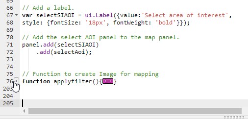

*You can ensure all elements are within the `applyFilter()` function by minimizing the function in the code editor by selecting the arrow next to it.*

## 5.6 Generating the Binary NDVI Maps

The functions for generating the binary and difference maps are fairly straightforward. Still it is worth defining all the component parts and the connections in a conceptual diagram before moving forward.

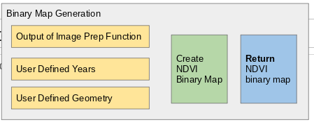

*Generalized workflow of the binary map production geoprocessing step.*

### 5.6.1 Establish Binary Panel Element

Before creating the geoprocessing steps, we will generate the panel element that will hold them.

```javascript
/*
Defining time frame for Binary MAP
*/

var durpanel = ui.Label({
  value:'Select Year for Landsat 30m Binary Map',
  style:{fontSize: '18px', fontWeight: 'bold'}});

var selectYr1 = ui.Textbox({placeholder: 'Year',  value: '2018',
  style: {width: '100px'}});

var datasetRange_label = ui.Label('Choose year from 1984 - 2018      ',
  {margin: '0 0 0 10px',fontSize: '12px',color: 'gray'});

panel.add(durpanel)
  .add(datasetRange_label)
  .add(selectYr1);
```

As with the previous examples, we are creating labels and adding them to the primary panel in the order we want them displayed.

We want users to be able to adjust what is considered to be “green” vegetation by altering where the line is drawn between vegetation or not within the GUI. This is an important step: to allow the user to adjust the presentation of the data based on the ecology of the selected river delta. NDVI values are based on a continuous scale and a slider bar is an appropriate widget for adjusting these type of values.

```javascript
// Add a slider bar widget.
var NDVIslider = ui.Slider();
// Set a default value.
NDVIslider.setValue(0.17);
NDVIslider.onChange(function(value) {
  Map.layers().get(0);
});
// Create a button that will run the function that creates the NDVI binary object.
var NDVIBINMAP = ui.Button({label:'Landsat NDVI Map' , onClick:NDVIBIN});
// Add slider and Button to the map.
panel.add(NDVIslider)
  .add(NDVIBINMAP);
```

There is quite a bit of new functionality listed in the code block above. Creating the slider follows the form of creating the labels and text boxes. Using the `setValue()` function allows us to define the initial value that will be used if the user does not make a change. The `onChange()` function is the first example of an **Event** object. An `onChange()` event looks for a change in the value on the slider. If this change occurs it grabs that new value. The `NDVIslider` object is a map layer because it is positioned on the panel on the map. The `onChange()` function is called on the map object `NDVIslider` and returns the first and only value.

### 5.6.2 Generating the Binary Map

The last variable in the function creates the `ui.Button`. This widget function has a built in event object within it. The `onClick` parameter will run a function once the click occurs. Below we will define how the function the `NDVIBIN()` will run when clicked.

```javascript
//Function to create a binary NDVI map for a user selected year and AOI.
function NDVIBIN (){
    applyFilter();
    var Nimage = Fimageyr1.expression(
    "NDVI >= thresh1", {
      'NDVI': Fimageyr1.select('NDVI').clip(geometry),
      'thresh1' : NDVIslider.getValue()}); //Slider bar input

      var NDVIMimage = Nimage.updateMask(Nimage.gt(0)); //Mask 0 values
      Map.centerObject(geometry); //Center on AOI
      Map.addLayer(NDVIMimage, VEG, 'NDVI Landsat Binary Map(' + yr1+ ')');
}
```

This function will create our first actual map output. When the user presses the “Landsat NDVI Map” button this function runs. If first calls the `applyFilter()` function returning a median reduced image from the Landsat collection based on the user defined year. From there we use an expression to determine all locations where NDVI is greater than the threshold value which is also defined by the user. After a quick mask to remove all the values that are lower than the threshold we add the image to map and center the map on the image so the user can view it immediately.

With both these elements in place we can see that our GUI is starting to grow.

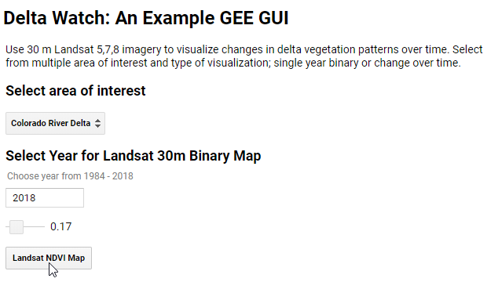

*GUI containing the binary map option.*

At this point if you tried to produce the `Landsat NDVI Map` it would fail because variables that are present in the `applyFilter()` function are not defined. We will get to these last elements now.

## 5.7 Generating the NDVI Difference Maps

In this case the difference maps are created by subtraction two images. Our final code will add the difference image and the two original images to the map.

```javascript
/*
Change maps
*/

// Generate a change map based on a user defined STARTYEAR, ENDYEAR, AND AOI.
function GREENER() {
    applyFilter();
    var date1 = Fimageyr2.select('NDVI'); //Select NDVI Values for Start Year
    var date2 = Fimageyr3.select('NDVI'); //Select NDVI values for End Year
    var diff = date2.subtract(date1); //Subtract rasters to get magnitude of change
    var trend = date2.gt(date1); //Creates a binary where pixels that have a greater NDVI in year two are assigned a value of 1
    var final = trend.multiply(diff).clip(geometry); //Shows magnitude for greening trend

    Map.centerObject(geometry); // Center on AOI
    Map.addLayer(final, MG, 'Areas that have become more green(' + yr2 + ')-(' + yr3 + ')');
    Map.addLayer(date1, visNDVI, 'NDVI (' + yr2 + ')', false); //Creates a layer with the index in the Start Year.
    Map.addLayer(date2, visNDVI, 'NDVI(' + yr3 + ')', false); //Creates a layer with the index in the End Year.
  }
// Same process for areas that decrease in greenness
function LESSGREEN() {
      applyFilter();
    var date1 = Fimageyr2.select('NDVI'); //Select NDVI Values for Start Year
    var date2 = Fimageyr3.select('NDVI'); //Select NDVI values for End Year
    var diff = date2.subtract(date1); //Subtract rasters to get maginitude of change
    var trend = date2.lt(date1); //Creates a binary where pixels that have a lesser NDVI in year two are assigned a value of 1
    var final = trend.multiply(diff).clip(geometry); //Shows magnitude for less green trend

    Map.centerObject(geometry); // Center on AOI
    Map.addLayer(final, LG, 'Areas that have become less green(' + yr2 + ')-(' + yr3 + ')');
    Map.addLayer(date1, visNDVI, 'NDVI(' + yr2 + ')', false); //Creates a layer with the index in the Start Year.
    Map.addLayer(date2, visNDVI, 'NDVI(' + yr3 + ')', false); //Creates a layer with the index in the End Year.
  };
```

Much like with the binary map, we’re calling the `applyFilter()` function to gather our imagery. The `gt` and `lt` functions threshold the value of the image. This defines the locations that have experienced loss or gain of NDVI values. The binary output of this function is multiplied by the difference between the two values. This ensures that only values expressing the direction of change are found in the final image.

### 5.7.1 Develop the Panel Elements for the Change Maps

Next we will add the GUI element for the change maps.

```javascript
// Define the textbox for the 1st and 2nd year.
var selectYr2 = ui.Textbox({placeholder: 'Year',  value: '1985',
  style: {width: '100px'}});
var selectYr3 = ui.Textbox({placeholder: 'Year',  value: '2018',
  style: {width: '100px'}});
// define the labels needed for GUI
var changepanel = ui.Label({
  value:'Select Years for Landsat 30m Change Map',
  style:{fontSize: '18px', fontWeight: 'bold'}});
var datasetRange_label2 = ui.Label('Start Year (1984 - )          ',
  {margin: '0 0 0 10px',fontSize: '12px',color: 'gray'});
var datasetRange_label3 = ui.Label('End Year (-2018)     ',
  {margin: '0 0 0 10px',fontSize: '12px',color: 'gray'});
// Create two buttons that will add the greener or lessGreen images to the map
var GRMAP = ui.Button('More Green Trend Map', GREENER);
var LGMAP = ui.Button('Less Green Trend Map', LESSGREEN);
// Add all elements to the panel in the correct order.
panel.add(changepanel)
  .add(ui.Panel([datasetRange_label2, datasetRange_label3],ui.Panel.Layout.flow('horizontal')))
  .add(ui.Panel([selectYr2, selectYr3],ui.Panel.Layout.flow('horizontal')))
  .add(GRMAP)
  .add(LGMAP);
```

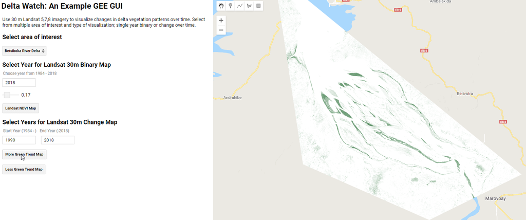

*With the final elements added we can run our binary and change maps. Here we show areas that have greened between 1990 and 2018 in the Betsiboka Delta.*

## 5.8 Resetting the map

The final function of the GUI is the rest button.

```javascript
var resetButton = ui.Button('Reset Map', reset);
panel.add(resetButton);
```

The same as all previous buttons, this element calls a `reset()` function when selected. The `reset()` function below allows the user to remove all the elements from the map giving them a clean slate to ask new questions.

```javascript
/*
Reset Map
*/
function reset(){
  Map.clear();
}
```

There we have it, a complete set of code for a functional GUI that gives us some important information about the changes in vegetation growth in three of our world’s deltas.

# 6 Conclusion

At the end of this process you will have a GEE script that generates a GUI that allow users to ask questions about changes in NDVI within three major river deltas over time. This ability to allow your end users and partners ask their own questions with remotely sensed data is a critical step toward integrating their expert knowledge into your work. While the methods within this module are not designed to answer specific management questions, adapting this code will allow you to start developing your own GUI tailored to the research questions relevant to your project stakeholders . Because this code can be engaged view a web browser, the end user of the GUI will be working with an interactive web map. These are the communication tools people want due to ease of use. So, while it takes a lot of planning and effort to make it happen it is always worth considering if adding these dynamic elements will be worth it. This is a question that should be answered by your end user because if you can keep them engaged it is far more likely that your content will be used.

## 6.1 Complete Code for GUI

```javascript
/*
Global Variables
*/
var aoi,
    areaOfInterest,
    Fimageyr1,Fimageyr2,Fimageyr3,
    geometry,
    thresh,
    yr1,yr2,yr3

/*
Visualization parameters
*/

var VEG = {"opacity":1,"palette":["2ddc0d"],"min":0,"max":1}
var MG = {"opacity":1, "palette":["ffffff", "085a16"], "min":0, "max":2}
var LG = {"opacity":1, "palette":["ff7c0b", "ffffff"], "min":-2, "max":0}
var visNDVI = {min: -1, max: 1, palette: ['blue', 'white', 'green']};
var FLG = {"opacity":1, "palette":[ "ffffff", "ff7c0b"], "min":0, "max":2}

/*
Create the panel
*/

// Generate main panel and add it to the map.
var panel = ui.Panel({style: {width:'33.333%'}});
ui.root.insert(0,panel);

// Define title and description.
var intro = ui.Label('Delta Watch: An Example GEE GUI ',
  {fontWeight: 'bold', fontSize: '24px', margin: '10px 5px'}
);
var subtitle = ui.Label('Use 30 m Landsat 5,7,8 imagery to'+
  ' visualize changes in delta vegetation patterns over time.'+
  ' Select from multiple area of interest and type of visualization; single year binary '+
  ' or change over time.', {});

// Add title and description to the panel
panel.add(intro).add(subtitle);
/*
Define study areas.
*/
// Generate polygons for each study region.
var colo = ee.Geometry.Polygon([[-115.29,32.20], [-114.89,31.17],
   [-114.40,31.64], [-115.14,32.19], [-115.29,32.20]]),
    nile = ee.Geometry.Polygon([[28.76,31.49],[30.69,29.91],
      [31.52, 29.96],[32.89,31.43],[31.00,31.76],[28.76,31.49]]),
    bets = ee.Geometry.Polygon([[46.19,-15.66],[46.25,-16.04],
      [46.51,-16.15],[46.70,-16.06],[46.19,-15.66]])

// Define labels for each study region.
var COLO = 'Colorado River Delta',
    NILE = 'Nile River Delta',
    BETS = 'Betsiboka River Delta'

/*
Select Area of INTEREST
*/

// Define the select button for the AOI
var selectAoi = ui.Select({
  items:[COLO,NILE,BETS],
  placeholder:'Select area of interest',
  });

// Add a label.
var selectSIAOI = ui.Label({value:'Select area of interest',
style: {fontSize: '18px', fontWeight: 'bold'}});

// Add the select AOI panel to the map panel.
panel.add(selectSIAOI)
    .add(selectAoi);

//Function to create a binary NDVI map for a user selected year and AOI.
function NDVIBIN (){
    applyFilter();
    var Nimage = Fimageyr1.expression(
    "NDVI >= thresh1", {
      'NDVI': Fimageyr1.select('NDVI').clip(geometry),
      'thresh1' : NDVIslider.getValue()}); //Slider bar input

      var NDVIMimage = Nimage.updateMask(Nimage.gt(0)); //Mask 0 values
      Map.centerObject(geometry); //Center on AOI
      Map.addLayer(NDVIMimage, VEG, 'NDVI Landsat Binary Map(' + yr1+ ')');
}

// Container function to create Image for mapping.
function applyFilter(){
/*
Defining the area of interested
*/

function setAreaOfInterest(){
  aoi = selectAoi.getValue();
  if (aoi == COLO){
      areaOfInterest = colo;
  }//sets the area to nile river delta
  else if(aoi == NILE){
      areaOfInterest = nile;
  }//sets the area of interest to
  else if (aoi == BETS){
      areaOfInterest = bets;
  }
}

setAreaOfInterest();

geometry = areaOfInterest

/*
Defining years for image selection
*/
    yr1 = selectYr1.getValue(); //Input for Landsat Binary Map
    yr2 = selectYr2.getValue(); //Input for Landsat Change Map Start Year
    yr3 = selectYr3.getValue(); //Input for Landsat Change Map End Year

/*
Creating image dictionaries.
*/

var constructLSDict = function(geometry)
  /*
  This function takes in a geometry feature from the GUI and uses it to
  generate a dictionary of median reduce images for the specified date
  range
  inputs
  geometry = defined by the GUI
  Features to change
  y_list = set based on sensor type
  imagecollection = unique id for collection type
  filterDate = cat() this is used to refine the month and day of start and end time
  With adaptation this should be flexible across sensors and times
  */
  {
  var startMonth = "-04-05"
  var endMonth = "-09-30"
  // Construct a dictionary for landsat 8 imagery.
  var y_list = ee.List.sequence(2013, 2018)
  var ystr_list = y_list.map(function(y){return ee.Number(y).format('%1d')})
  var ls8 = y_list.map(function(y){return ee.ImageCollection('LANDSAT/LC08/C01/T1_SR')
                                          .filterDate(ee.String(ee.Number(y).format('%1d')).cat(startMonth),
                                                      ee.String(ee.Number(y).format('%1d')).cat(endMonth))
                                          .filterBounds(geometry)
                                          .filterMetadata('CLOUD_COVER', 'less_than', 30)
                                          .median()})
  var ls8_dict = ee.Dictionary.fromLists(ystr_list, ls8);

  // Construct a dictionary for LS7 imagery
  var y_list7 = ee.List.sequence(2012, 2012)
  var ystr_list7 = y_list7.map(function(y){return ee.Number(y).format('%1d')})
  var ls7 = y_list7.map(function(y){return ee.ImageCollection('LANDSAT/LE07/C01/T1_SR')
                                          .filterDate(ee.String(ee.Number(y).format('%1d')).cat(startMonth),
                                                      ee.String(ee.Number(y).format('%1d')).cat(endMonth))
                                          .filterBounds(geometry)
                                          .filterMetadata('CLOUD_COVER', 'less_than', 30)
                                          .median()})
  var ls7_dict = ee.Dictionary.fromLists(ystr_list7, ls7);

  // Combine the LS8 and LS7 dictionaries.
  var ls8_ls7_dict = ls8_dict.combine(ls7_dict)

  // Construct a dictionary for Landsat 5.
  var y_list5 = ee.List.sequence(1984,2011)
  var ystr_list5 = y_list5.map(function(y){return ee.Number(y).format('%1d')})
  var ls5 = y_list5.map(function(y){return ee.ImageCollection('LANDSAT/LT05/C01/T1_SR')
                                          .filterDate(ee.String(ee.Number(y).format('%1d')).cat(startMonth),
                                                      ee.String(ee.Number(y).format('%1d')).cat(endMonth))
                                          .filterBounds(geometry)
                                          .filterMetadata('CLOUD_COVER', 'less_than', 30)
                                          .median()})
  var ls5_dict = ee.Dictionary.fromLists(ystr_list5, ls5);
  // Combine the LS5 with the LS8/7 dictionary
  var LS_Dict = ls8_ls7_dict.combine(ls5_dict)

  return(LS_Dict)
}

/*
Generating indices
*/
// A function to compute NDVI for Landsat 5 and 7.
var NDVI57 = function(image) {
  return image.normalizedDifference(["B4","B3"]).rename("NDVI");
};

// A function to compute NDVI for Landsat 8.
var NDVI8 = function(image) {
  return image.normalizedDifference(["B5","B4"]).rename("NDVI");
};


/*
Selecting bands based on years
*/

var selectYearAddBands = function(dictionary, year, geometry)
{
    if (year >= 2012) {
      var imageYear = ee.Image(dictionary.get(year)).clip(geometry)
      var outImage = imageYear.addBands(NDVI8(imageYear))
    } else if (year == 2011) {
      var imageYear = ee.Image(dictionary.get(year)).clip(geometry)
      var outImage = imageYear.addBands(NDVI57(imageYear))
    } else {
      var imageYear = ee.Image(dictionary.get(year)).clip(geometry)
      var outImage = imageYear.addBands(NDVI57(imageYear))
    }
  return (outImage)
};


// Make LS Dictionary and Select years of interest.
var dict_ls = constructLSDict(geometry);
  Fimageyr1 = selectYearAddBands(dict_ls, yr1, geometry); //LS BINARY
  Fimageyr2 = selectYearAddBands(dict_ls, yr2, geometry); //LS Change Start Year
  Fimageyr3 = selectYearAddBands(dict_ls, yr3, geometry); //LS Change End Year

}


/*
Defining time frame for Binary MAP
*/

var durpanel = ui.Label({
  value:'Select Year for Landsat 30m Binary Map',
  style:{fontSize: '18px', fontWeight: 'bold'}});

var selectYr1 = ui.Textbox({placeholder: 'Year',  value: '2018',
  style: {width: '100px'}});

var datasetRange_label = ui.Label('Choose year from 1984 - 2018      ',
  {margin: '0 0 0 10px',fontSize: '12px',color: 'gray'});

panel.add(durpanel)
  .add(datasetRange_label)
  .add(selectYr1);

// Add a slider bar widget
var NDVIslider = ui.Slider();
// Set a default value.
NDVIslider.setValue(0.17);
NDVIslider.onChange(function(value) {
  Map.layers().get(0);
});
// Create a button that will run the function that creates the NDVI binary object
var NDVIBINMAP = ui.Button({label:'Landsat NDVI Map' , onClick:NDVIBIN});
// Add slider and Button to the map.
panel.add(NDVIslider)
  .add(NDVIBINMAP)

/*
Change maps
*/

// Generate a change map based on a user defined STARTYEAR, ENDYEAR, AND AOI.
function GREENER() {
    applyFilter();
    var date1 = Fimageyr2.select('NDVI'); //Select NDVI Values for Start Year
    var date2 = Fimageyr3.select('NDVI'); //Select NDVI values for End Year
    var diff = date2.subtract(date1); //Subtract rasters to get maginitude of change
    var trend = date2.gt(date1); //Creates a binary where pixels that have a greater NDVI in year two are assigned a value of 1
    var final = trend.multiply(diff).clip(geometry); //Shows magnitude for greening trend

    Map.centerObject(geometry); // Center on AOI
    Map.addLayer(final, MG, 'Areas that have become more green(' + yr2 + ')-(' + yr3 + ')');
    Map.addLayer(date1, visNDVI, 'NDVI (' + yr2 + ')', false); //Creates a layer with the index in the Start Year.
    Map.addLayer(date2, visNDVI, 'NDVI(' + yr3 + ')', false); //Creates a layer with the index in the End Year.
  }
// Same process for areas that decrease in greenness
function LESSGREEN() {
      applyFilter();
    var date1 = Fimageyr2.select('NDVI'); //Select NDVI Values for Start Year
    var date2 = Fimageyr3.select('NDVI'); //Select NDVI values for End Year
    var diff = date2.subtract(date1); //Subtract rasters to get magnitude of change
    var trend = date2.lt(date1); //Creates a binary where pixels that have a lesser NDVI in year two are assigned a value of 1
    var final = trend.multiply(diff).clip(geometry); //Shows magnitude for less green trend

    Map.centerObject(geometry); // Center on AOI
    Map.addLayer(final, LG, 'Areas that have become less green(' + yr2 + ')-(' + yr3 + ')');
    Map.addLayer(date1, visNDVI, 'NDVI(' + yr2 + ')', false); //Creates a layer with the index in the Start Year.
    Map.addLayer(date2, visNDVI, 'NDVI(' + yr3 + ')', false); //Creates a layer with the index in the End Year.
  }

// Define the textbox for the 1st and 2nd year
var selectYr2 = ui.Textbox({placeholder: 'Year',  value: '1985',
  style: {width: '100px'}});
var selectYr3 = ui.Textbox({placeholder: 'Year',  value: '2018',
  style: {width: '100px'}});
// define the labels needed for GUI
var changepanel = ui.Label({
  value:'Select Years for Landsat 30m Change Map',
  style:{fontSize: '18px', fontWeight: 'bold'}});
var datasetRange_label2 = ui.Label('Start Year (1984 - )          ',
  {margin: '0 0 0 10px',fontSize: '12px',color: 'gray'});
var datasetRange_label3 = ui.Label('End Year (-2018)     ',
  {margin: '0 0 0 10px',fontSize: '12px',color: 'gray'});
// Create two buttons that will add the greener or lessGreen images to the map
var GRMAP = ui.Button('More Green Trend Map', GREENER);
var LGMAP = ui.Button('Less Green Trend Map', LESSGREEN);
// Add all elements to the panel in the correct order.
panel.add(changepanel)
  .add(ui.Panel([datasetRange_label2, datasetRange_label3],ui.Panel.Layout.flow('horizontal')))
  .add(ui.Panel([selectYr2, selectYr3],ui.Panel.Layout.flow('horizontal')))
  .add(GRMAP)
  .add(LGMAP);

var resetButton = ui.Button('Reset Map', reset);
panel.add(resetButton);

/*
Reset Map
*/
function reset(){
  Map.clear();
}
```